# Project Python Foundations: FoodHub Data Analysis

#### Project Submitted by : Sivaramkumar Mani

### Context

The number of restaurants in New York is increasing day by day. Lots of students and busy professionals rely on those restaurants due to their hectic lifestyles. Online food delivery service is a great option for them. It provides them with good food from their favorite restaurants. A food aggregator company FoodHub offers access to multiple restaurants through a single smartphone app.

The app allows the restaurants to receive a direct online order from a customer. The app assigns a delivery person from the company to pick up the order after it is confirmed by the restaurant. The delivery person then uses the map to reach the restaurant and waits for the food package. Once the food package is handed over to the delivery person, he/she confirms the pick-up in the app and travels to the customer's location to deliver the food. The delivery person confirms the drop-off in the app after delivering the food package to the customer. The customer can rate the order in the app. The food aggregator earns money by collecting a fixed margin of the delivery order from the restaurants.

### Objective

The food aggregator company has stored the data of the different orders made by the registered customers in their online portal. They want to analyze the data to get a fair idea about the demand of different restaurants which will help them in enhancing their customer experience. Suppose you are hired as a Data Scientist in this company and the Data Science team has shared some of the key questions that need to be answered. Perform the data analysis to find answers to these questions that will help the company to improve the business.

### Data Description

The data contains the different data related to a food order. The detailed data dictionary is given below.

### Data Dictionary

- order_id: Unique ID of the order
- customer_id: ID of the customer who ordered the food
- restaurant_name: Name of the restaurant
- cuisine_type: Cuisine ordered by the customer
- cost_of_the_order: Cost of the order
- day_of_the_week: Indicates whether the order is placed on a weekday or weekend (The weekday is from Monday to Friday and the weekend is Saturday and Sunday)
- rating: Rating given by the customer out of 5
- food_preparation_time: Time (in minutes) taken by the restaurant to prepare the food. This is calculated by taking the difference between the timestamps of the restaurant's order confirmation and the delivery person's pick-up confirmation.
- delivery_time: Time (in minutes) taken by the delivery person to deliver the food package. This is calculated by taking the difference between the timestamps of the delivery person's pick-up confirmation and drop-off information

### Let us start by importing the required libraries

```python
# import libraries for data manipulation

import numpy as np
import pandas as pd

# import libraries for data visualization
import matplotlib.pyplot as plt
import seaborn as sns
```

### Understanding the structure of the data

```python
# uncomment and run the following lines for Google Colab
from google.colab import drive
drive.mount('/content/drive')
```

```python
# Loading foodhub.csv from google drive
path="/content/drive/MyDrive/foodhub_order.csv"

data = pd.read_csv(path)
```

```python
# Functions

def add_percentage_count(df):
  count_table = df.value_counts().sort_values(ascending=False).reset_index()
  count_table["percentage"] = round((count_table['count']/df.shape[0])*100,2)
  return count_table
```

```python
# Write your code here to view the first 5 rows
data.head(5)
```

|  | order_id | customer_id | restaurant_name | cuisine_type | cost_of_the_order | day_of_the_week | rating | food_preparation_time | delivery_time |
| --- | --- | --- | --- | --- | --- | --- | --- | --- | --- |
| 0 | 1477147 | 337525 | Hangawi | Korean | 30.75 | Weekend | Not given | 25 | 20 |
| 1 | 1477685 | 358141 | Blue Ribbon Sushi Izakaya | Japanese | 12.08 | Weekend | Not given | 25 | 23 |
| 2 | 1477070 | 66393 | Cafe Habana | Mexican | 12.23 | Weekday | 5 | 23 | 28 |
| 3 | 1477334 | 106968 | Blue Ribbon Fried Chicken | American | 29.20 | Weekend | 3 | 25 | 15 |
| 4 | 1478249 | 76942 | Dirty Bird to Go | American | 11.59 | Weekday | 4 | 25 | 24 |

### **Question 1:** How many rows and columns are present in the data? [0.5 mark]

```python
rows,columns = data.shape

print("Total rows :" + str(rows))
print("Total Columns :" + str(columns))
```

```
Total rows :1898
Total Columns :9
```

#### **Observations**:

Total Rows in the data : 1898

Total Columns in the data : 9

### **Question 2:** What are the datatypes of the different columns in the dataset? (The info() function can be used) [0.5 mark]

```python
data.info()
```

```
<class 'pandas.core.frame.DataFrame'>
RangeIndex: 1898 entries, 0 to 1897
Data columns (total 9 columns):
 #   Column                 Non-Null Count  Dtype
---  ------                 --------------  -----
 0   order_id               1898 non-null   int64
 1   customer_id            1898 non-null   int64
 2   restaurant_name        1898 non-null   object
 3   cuisine_type           1898 non-null   object
 4   cost_of_the_order      1898 non-null   float64
 5   day_of_the_week        1898 non-null   object
 6   rating                 1898 non-null   object
 7   food_preparation_time  1898 non-null   int64
 8   delivery_time          1898 non-null   int64
dtypes: float64(1), int64(4), object(4)
memory usage: 133.6+ KB
```

#### **Observations**:

order_id (int64)

customer_id (int64)

restaurant_name (object)

cuisine_type (object)

cost_of_the_order (float64)

day_of_the_week (object)

rating (object)

food_preparation_time (int64)

delivery_time (int64)

There are 3 different data types in the data: float (1): cost_of_the_order int64 (4): order_id, customer_id, food_preparation_time, delivery_time object (4): restaurant_name, cuisine_type, day_of_the_week, rating The rating column contains numeric values, however, it is being read as a object data type due to the string values 'Not given'.

### **Question 3:** Are there any missing values in the data? If yes, treat them using an appropriate method. [1 mark]

```python
# Count missing values per column
print(data.isnull().sum())

# Total missing values
print("Total missing values :", str(data.isnull().sum().sum()))
```

```
order_id                 0
customer_id              0
restaurant_name          0
cuisine_type             0
cost_of_the_order        0
day_of_the_week          0
rating                   0
food_preparation_time    0
delivery_time            0
dtype: int64
Total missing values : 0
```

```python
# Checking for duplicate Orders
data.duplicated().sum()
```

```
np.int64(0)
```

#### **Observations**:

1. There are no missing vlaues in any columns.
2. There are no duplicate orders in the data

### **Question 4:** Check the statistical summary of the data. What is the minimum, average, and maximum time it takes for food to be prepared once an order is placed? [2 marks]

```python
# Chec Statistical informaiton on the data
data.describe().T
```

|  | count | mean | std | min | 25% | 50% | 75% | max |
| --- | --- | --- | --- | --- | --- | --- | --- | --- |
| order_id | 1898.0 | 1.477496e+06 | 548.049724 | 1476547.00 | 1477021.25 | 1477495.50 | 1.477970e+06 | 1478444.00 |
| customer_id | 1898.0 | 1.711685e+05 | 113698.139743 | 1311.00 | 77787.75 | 128600.00 | 2.705250e+05 | 405334.00 |
| cost_of_the_order | 1898.0 | 1.649885e+01 | 7.483812 | 4.47 | 12.08 | 14.14 | 2.229750e+01 | 35.41 |
| food_preparation_time | 1898.0 | 2.737197e+01 | 4.632481 | 20.00 | 23.00 | 27.00 | 3.100000e+01 | 35.00 |
| delivery_time | 1898.0 | 2.416175e+01 | 4.972637 | 15.00 | 20.00 | 25.00 | 2.800000e+01 | 33.00 |

```python
# Display the count of unique categorical values in each column
for col in data.columns:
  print(data[col].value_counts())
  print('-' * 50)
```

```
order_id
1478056    1
1477147    1
1477685    1
1477070    1
1477334    1
          ..
1478198    1
1477449    1
1476966    1
1478437    1
1477895    1
Name: count, Length: 1898, dtype: int64
--------------------------------------------------
customer_id
52832     13
47440     10
83287      9
250494     8
259341     7
          ..
143926     1
89574      1
157711     1
66393      1
358141     1
Name: count, Length: 1200, dtype: int64
--------------------------------------------------
restaurant_name
Shake Shack                  219
The Meatball Shop            132
Blue Ribbon Sushi            119
Blue Ribbon Fried Chicken     96
Parm                          68
                            ...
Rye House                      1
Hiroko's Place                 1
Frank Restaurant               1
Sarabeth's West                1
'wichcraft                     1
```

[output cut: 71 more lines]

```
25    120
19     90
16     90
20     88
15     87
22     85
18     83
21     81
17     78
23     77
32     59
33     49
31     41
Name: count, dtype: int64
--------------------------------------------------
```

#### **Observations**:

Minimum time taken to prepare the food on orders : 20.00

Maximum time taken to prepare the food on orders : 35.00

Average time taken to prepare the food on orders : 27.37

### **Question 5:** How many orders are not rated? [1 mark]

```python
# understand the valrious values used to not provide rating
unique_review_values = data['rating'].unique()
print(unique_review_values)
```

```
['Not given' '5' '3' '4']
```

```python
# Not given is the only value used to represent missing reviews

# Count total records with review value "Not given"

missing_rating_rows = data[data['rating'] == "Not given"]

print(f"Total rows missing reviews : {missing_rating_rows.shape [0]}, percentage {(missing_rating_rows.shape [0]/data.shape[0])*100}%", )
```

```
Total rows missing reviews : 736, percentage 38.77766069546891%
```

#### **Observations**:

1. Total rows with missing rating : 736 (38.78% of the data)
2. So normalizing it to a rating will skewe the distribution so we will just drop

### Exploratory Data Analysis (EDA)

### **Question 6:** Explore all the variables and provide observations on their distributions. (Generally, histograms, boxplots, countplots, etc. are used for univariate exploration.) [9 marks]

**Univariate analysis : Customer Id**

```python
# Get Unique number of customers

print(f"Observation : There are {data['customer_id'].nunique()} customers based on Customer Id")
```

```
Observation : There are 1200 customers based on Customer Id
```

**Univariate analysis : Restaurant name**

```python
#Get number of unique restaurants

print(f"Observation : There are {data['restaurant_name'].nunique()} restaurants")
```

```
Observation : There are 178 restaurants
```

```python
# Order density per restaurant. Count plot will be roo large and dificult to understand
data['restaurant_name'].value_counts().sort_values(ascending=False)
```

| restaurant_name | count |
| --- | --- |
| Shake Shack | 219 |
| The Meatball Shop | 132 |
| Blue Ribbon Sushi | 119 |
| Blue Ribbon Fried Chicken | 96 |
| Parm | 68 |
| ... | ... |
| Rye House | 1 |
| Hiroko's Place | 1 |
| Frank Restaurant | 1 |
| Sarabeth's West | 1 |
| 'wichcraft | 1 |

178 rows × 1 columns

**dtype:** int64

**Observations** :

1. There are 178 unique restaurants
2. Shake Shack has the most orders

**Univariate analysis : Cuisine Type**

```python
#Get number of unique cousines

print(f"Observation : There are {data['cuisine_type'].nunique()} unique cuisine types")
```

```
Observation : There are 14 unique cuisine types
```

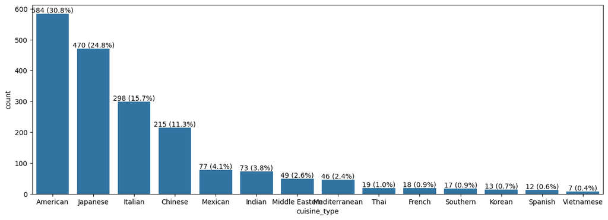

```python
## countplot for cuisine type.
plt.figure(figsize = (15,5))
cuisines_count = sns.countplot(data = data, x = 'cuisine_type',order=data['cuisine_type'].value_counts(ascending=False).index)
abs_values = data['cuisine_type'].value_counts(ascending=False).values
rel_values = data['cuisine_type'].value_counts(ascending=False, normalize=True).values * 100
lbls = [f'{p[0]} ({p[1]:.1f}%)' for p in zip(abs_values, rel_values)]
cuisines_count.bar_label(container=cuisines_count.containers[0], labels=lbls)
plt.show()
```

**Observation** :

1. There are 14 unique cuisines
2. Most Popular Cuisine is American(31%) followed by Japanese(25%) and Italian(16%) cuisine

**Univariate analysis : Day of the week**

```python
# Get order distribution during by day of the week
day_of_week_data = data['day_of_the_week'].value_counts().sort_values(ascending=False).reset_index()
day_of_week_data['percentage'] = (day_of_week_data['count']/data.shape[0])*100
day_of_week_data
```

|  | day_of_the_week | count | percentage |
| --- | --- | --- | --- |
| 0 | Weekend | 1351 | 71.18019 |
| 1 | Weekday | 547 | 28.81981 |

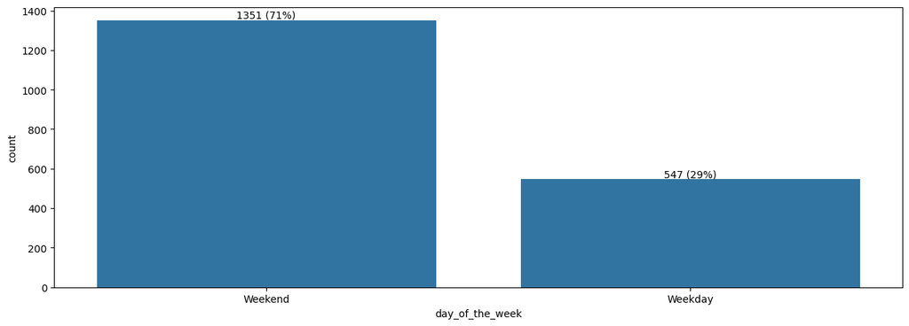

```python
plt.figure(figsize = (15,5))
day_of_week_count = sns.countplot(data = data, x = 'day_of_the_week',order=data['day_of_the_week'].value_counts(ascending=False).index)
abs_values = data['day_of_the_week'].value_counts(ascending=False).values
rel_values = data['day_of_the_week'].value_counts(ascending=False, normalize=True).values * 100
lbls = [f'{p[0]} ({p[1]:.0f}%)' for p in zip(abs_values, rel_values)]
day_of_week_count.bar_label(container=day_of_week_count.containers[0], labels=lbls)
plt.show()
```

**Observation** :

1. There are more oders during weekend (71% of orders happened in weekends) and 29% of orders happended on weekdays

**Univariate analysis : Food Preperation Time**

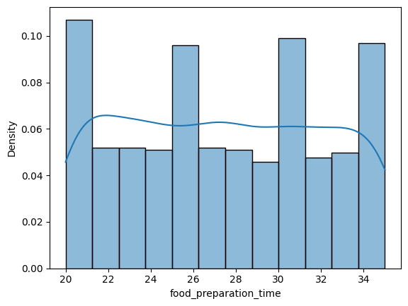

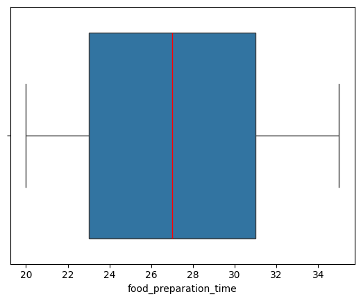

```python
# Distribution and Distance observations for numerical columns

sns.histplot(data=data,x='food_preparation_time',stat='density',kde=True)
plt.show()
sns.boxplot(data=data,x='food_preparation_time', medianprops = {'color': 'r'})
plt.show()
```

```python
data['food_preparation_time'].mean()
```

```
np.float64(27.371970495258168)
```

```python
data['food_preparation_time'].mode()
```

|  | food_preparation_time |
| --- | --- |
| 0 | 21 |

**dtype:** int64

```python
data['food_preparation_time'].max()
```

```
35
```

```python
data['food_preparation_time'].min()
```

```
20
```

#### **Observations**

1. Food Preperation time is not skewed
2. Maximum Food Prepration time is 35
3. Minimum Food Prepration time is 20
4. Most common Food Prepration time is 21
5. Average Food Prepration time overall is 27.372

**Univariat Analysis : Food delivery Time**

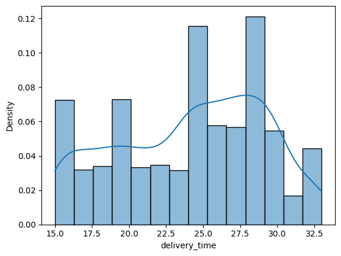

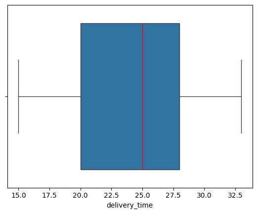

```python
sns.histplot(data=data,x='delivery_time',stat='density',kde=True)
plt.show()
sns.boxplot(data=data,x='delivery_time',medianprops = {'color': 'r'})
plt.show()
```

```python
data['delivery_time'].mean()
```

```
np.float64(24.161749209694417)
```

```python
data['delivery_time'].mode()
```

|  | delivery_time |
| --- | --- |
| 0 | 24 |

**dtype:** int64

```python
data['delivery_time'].max()
```

```
33
```

```python
data['delivery_time'].min()
```

```
15
```

**Observations**

1. Delivery time is slightly skewed left
2. Average delivery time : 24.162
3. Most common delivery time : 24
4. Maximum delivery time : 33
5. Minimum delivery time : 15

**Univariat Analaysis : cost_of_the_order**

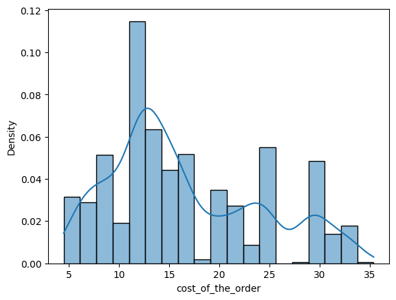

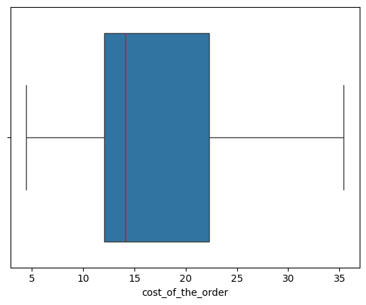

```python
sns.histplot(data=data,x='cost_of_the_order',stat='density', kde=True)
plt.show()
sns.boxplot(data=data,x='cost_of_the_order',medianprops = {'color': 'r'})
plt.show()
```

```python
data['cost_of_the_order'].mean()
```

```
np.float64(16.498851422550054)
```

```python
data['cost_of_the_order'].mode()
```

|  | cost_of_the_order |
| --- | --- |
| 0 | 12.18 |

**dtype:** float64

```python
data['cost_of_the_order'].max()
```

```
35.41
```

```python
data['cost_of_the_order'].min()
```

```
4.47
```

**Univariat Analysis : Rating**

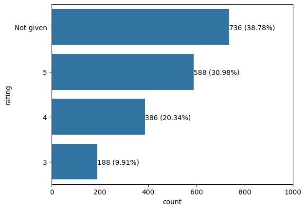

```python
order = data['rating'].value_counts().index
ax = sns.countplot(data = data, y = 'rating', order = order)
for patch in ax.patches:
  x = patch.get_x() + patch.get_width()
  y = patch.get_y() + patch.get_height() / 1.75
  cnt = ('{:.0f}').format(patch.get_width())
  pct = ('{:.2f}%').format(100 * patch.get_width() / len(data))
  ax.annotate((cnt + ' (' + pct + ')'), (x, y))
plt.xlim(0, 1000)
plt.show()
```

**Observations**

### **Question 7**: Which are the top 5 restaurants in terms of the number of orders received? [1 mark]

```python
top_restaurants = add_percentage_count(data['restaurant_name'])
top_restaurants.head(10)
```

|  | restaurant_name | count | percentage |
| --- | --- | --- | --- |
| 0 | Shake Shack | 219 | 11.54 |
| 1 | The Meatball Shop | 132 | 6.95 |
| 2 | Blue Ribbon Sushi | 119 | 6.27 |
| 3 | Blue Ribbon Fried Chicken | 96 | 5.06 |
| 4 | Parm | 68 | 3.58 |
| 5 | RedFarm Broadway | 59 | 3.11 |
| 6 | RedFarm Hudson | 55 | 2.90 |
| 7 | TAO | 49 | 2.58 |
| 8 | Han Dynasty | 46 | 2.42 |
| 9 | Blue Ribbon Sushi Bar & Grill | 44 | 2.32 |

**Answer**

1. Shake Shack 219
2. The Meatball Shop 132
3. Blue Ribbon Sushi 119
4. Blue Ribbon Fried Chicken 96
5. Parm 68

### **Question 8**: Which is the most popular cuisine on weekends? [1 mark]

```python
top_cuisines = add_percentage_count(data[data['day_of_the_week']=="Weekend"]['cuisine_type'])
top_cuisines
```

|  | cuisine_type | count | percentage |
| --- | --- | --- | --- |
| 0 | American | 415 | 30.72 |
| 1 | Japanese | 335 | 24.80 |
| 2 | Italian | 207 | 15.32 |
| 3 | Chinese | 163 | 12.07 |
| 4 | Mexican | 53 | 3.92 |
| 5 | Indian | 49 | 3.63 |
| 6 | Middle Eastern | 32 | 2.37 |
| 7 | Mediterranean | 32 | 2.37 |
| 8 | Thai | 15 | 1.11 |
| 9 | French | 13 | 0.96 |
| 10 | Korean | 11 | 0.81 |
| 11 | Southern | 11 | 0.81 |
| 12 | Spanish | 11 | 0.81 |
| 13 | Vietnamese | 4 | 0.30 |

#### **Answer**:

Most popular cusine during weekends is American, followed by Japanese and Italian.

### **Question 9**: What percentage of the orders cost more than 20 dollars? [2 marks]

```python
# Display the percentage of orders that cost below or greater than 20 dollars
greater_20_pct = data.apply(lambda df: True if df['cost_of_the_order'] > 20 else False, axis = 1).value_counts(normalize = True).mul(100).reset_index().rename(columns = {'index': 'is_cost_greater_20', 0: 'percentage'})
greater_20_pct
```

|  | is_cost_greater_20 | proportion |
| --- | --- | --- |
| 0 | False | 70.758693 |
| 1 | True | 29.241307 |

```python
# Display the percentage of orders that cost more than 20 dollars
greater_20_pct[greater_20_pct['is_cost_greater_20'] == True]
```

|  | is_cost_greater_20 | proportion |
| --- | --- | --- |
| 1 | True | 29.241307 |

#### **Observations**:

1. 29.24% of the orders cost more than 20 dollars.
2. While 70.76% of the orders cost less than or equal to 20 dollars.

### **Question 10**: What is the mean order delivery time? [1 mark]

```python
print(f"Mean order delivery time : {round(data['delivery_time'].mean(),2)}")
```

```
Mean order delivery time : 24.16
```

#### **Observations**:

Mean order delivery time is 24.16 Minutes

### **Question 11:** The company has decided to give 20% discount vouchers to the top 3 most frequent customers. Find the IDs of these customers and the number of orders they placed. [1 mark]

```python
data['customer_id'].value_counts().head(3).reset_index()
```

|  | customer_id | count |
| --- | --- | --- |
| 0 | 52832 | 13 |
| 1 | 47440 | 10 |
| 2 | 83287 | 9 |

#### **Observations**:

Top 3 customers

1. 52832 (13 orders)
2. 47440 (10 orders)
3. 83287 (9 orders)

### **Question 12**: Perform a multivariate analysis to explore relationships between the important variables in the dataset. (It is a good idea to explore relations between numerical variables as well as relations between numerical and categorical variables) [10 marks]

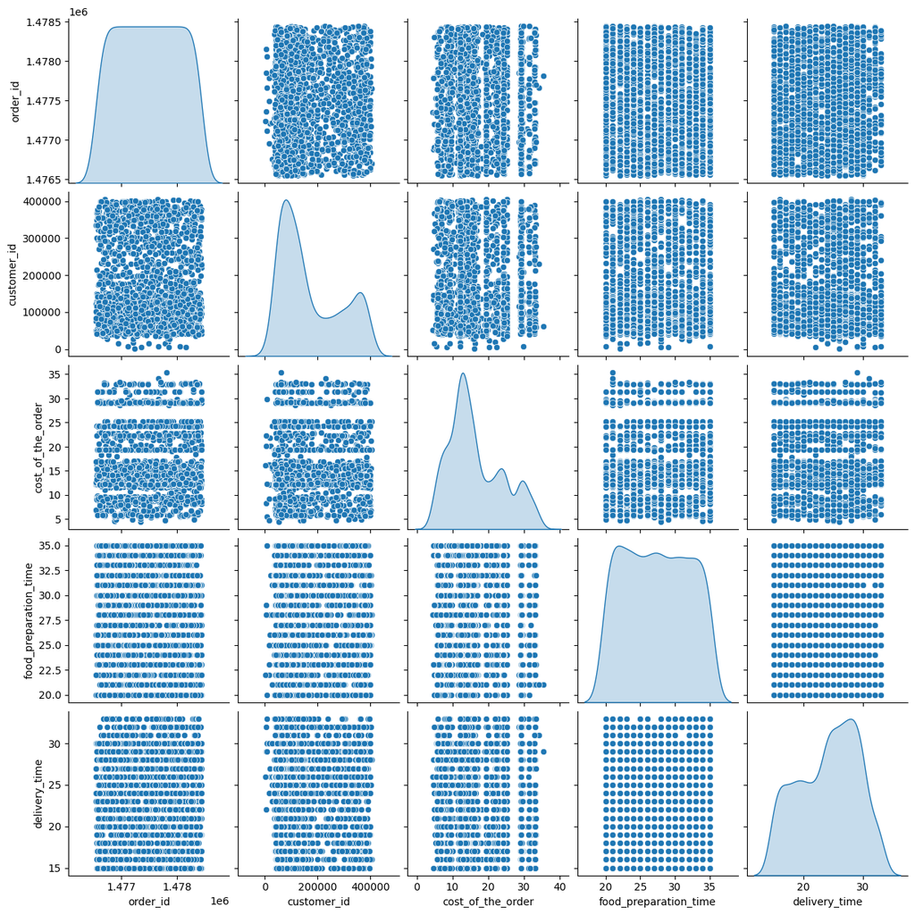

```python
# Display the relationship of numerical columns (order_id, customer_id, cost_of_the_order, food_preparation_time, delivery_time)
numeric_cols = ['order_id', 'customer_id', 'cost_of_the_order', 'food_preparation_time', 'delivery_time']
df = data[numeric_cols]

ax = sns.pairplot(data = df, diag_kind = 'kde')

plt.show()
```

```python
# Skip all row without ratings

data_with_ratings = data[data['rating'] != 'Not given']
# convert all ratings to integers
data_with_ratings[data_with_ratings['rating']=='5'].head(3)
```

|  | order_id | customer_id | restaurant_name | cuisine_type | cost_of_the_order | day_of_the_week | rating | food_preparation_time | delivery_time |
| --- | --- | --- | --- | --- | --- | --- | --- | --- | --- |
| 2 | 1477070 | 66393 | Cafe Habana | Mexican | 12.23 | Weekday | 5 | 23 | 28 |
| 8 | 1477174 | 121706 | Anjappar Chettinad | Indian | 16.44 | Weekday | 5 | 21 | 26 |
| 9 | 1477311 | 39705 | Bukhara Grill | Indian | 7.18 | Weekday | 5 | 29 | 26 |

**Observations**

**Rating vs Cost of Order**

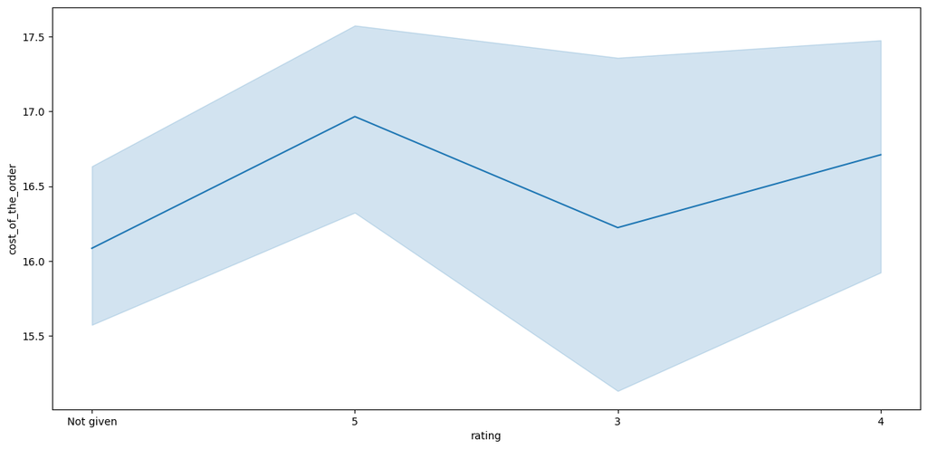

```python
# Relationship between rating and cost of the order
plt.figure(figsize=(15, 7))
sns.lineplot(x = 'rating', y = 'cost_of_the_order', data = data)
plt.show()
```

**Observation**

**Rating vs Delivery time**

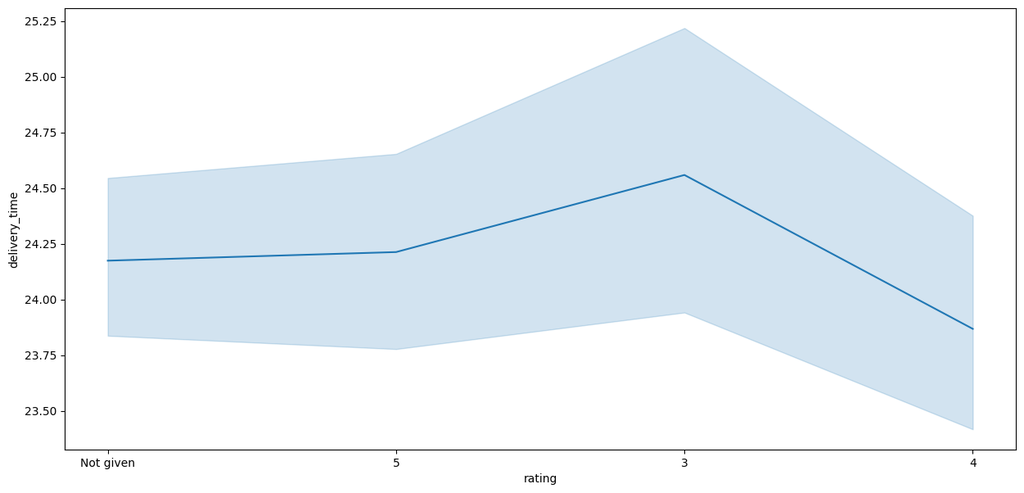

```python
# Relationship between rating and delivery time
plt.figure(figsize=(15, 7))
sns.lineplot(x = 'rating', y = 'delivery_time', data = data)
plt.show()
```

**Observation**

**Rating vs Food preparation time**

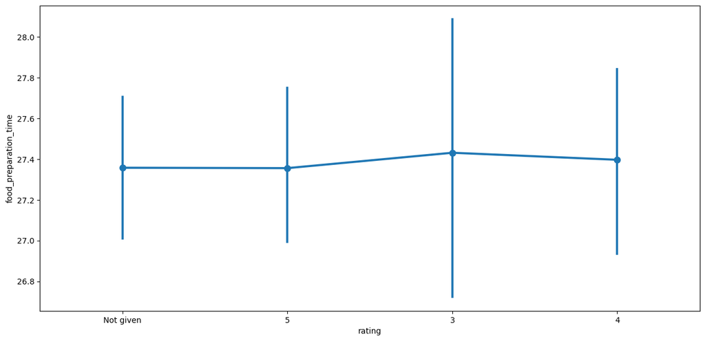

```python
# Relationship between rating and food preparation time
plt.figure(figsize=(15, 7))
sns.pointplot(x = 'rating', y = 'food_preparation_time', data = data)
plt.show()
```

**Cuisine vs Cost of the order**

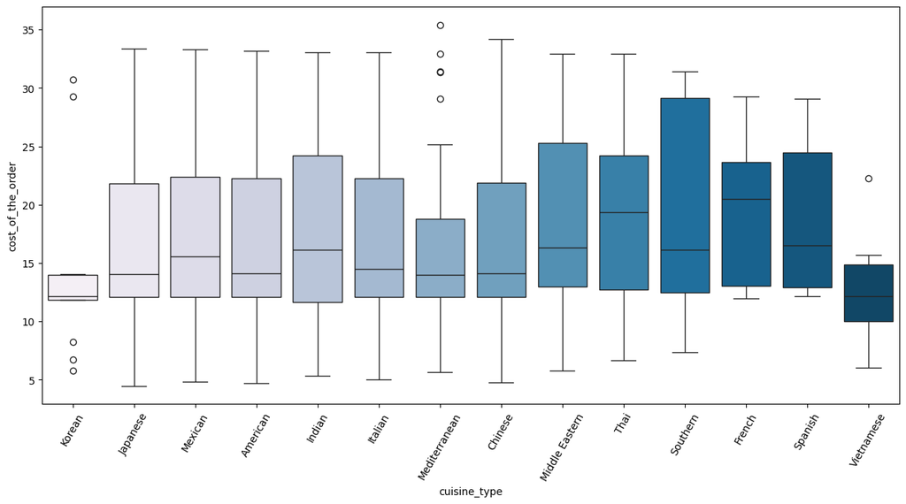

```python
# Relationship between cost of the order and cuisine type
plt.figure(figsize=(15,7))
sns.boxplot(x = "cuisine_type", y = "cost_of_the_order", data = data, palette = 'PuBu', hue = "cuisine_type")
plt.xticks(rotation = 60)
plt.show()
```

**Cuisine vs Food Preparation time**

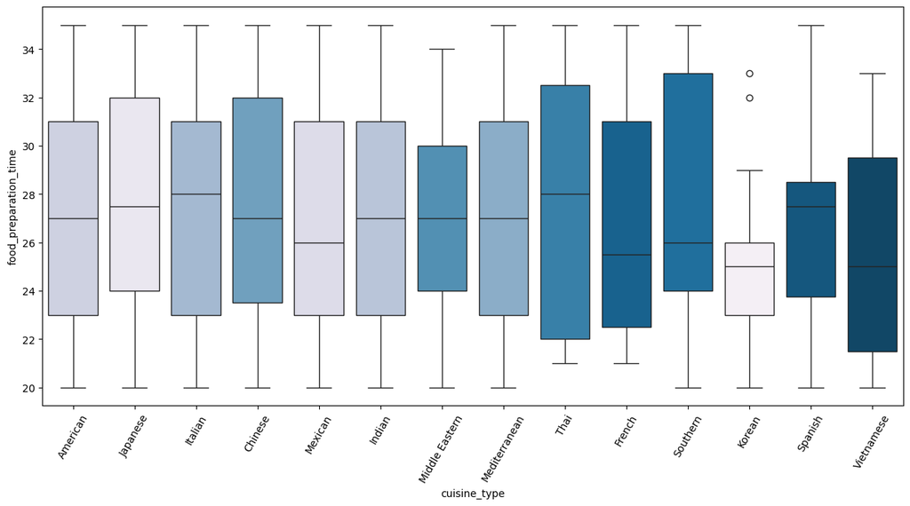

```python
# Relationship between food preparation time and cuisine type
plt.figure(figsize=(15,7))
order = data['cuisine_type'].value_counts().index
sns.boxplot(data = data,x = "cuisine_type", y = "food_preparation_time", palette = 'PuBu', hue = "cuisine_type", order=order)
plt.xticks(rotation = 60)
plt.show()
```

[figure not shown]

```python
plt.figure(figsize=(15,7))
sns.boxplot(x = "cuisine_type", y = "day_of_the_week", data = data, palette = 'PuBu', hue = "cuisine_type")
plt.show()
```

```python
data.groupby(['restaurant_name'])['cost_of_the_order'].sum().sort_values(ascending = False).head(15)
```

| restaurant_name | cost_of_the_order |
| --- | --- |
| Shake Shack | 3579.53 |
| The Meatball Shop | 2145.21 |
| Blue Ribbon Sushi | 1903.95 |
| Blue Ribbon Fried Chicken | 1662.29 |
| Parm | 1112.76 |
| RedFarm Broadway | 965.13 |
| RedFarm Hudson | 921.21 |
| TAO | 834.50 |
| Han Dynasty | 755.29 |
| Blue Ribbon Sushi Bar & Grill | 666.62 |
| Rubirosa | 660.45 |
| Sushi of Gari 46 | 640.87 |
| Nobu Next Door | 623.67 |
| Five Guys Burgers and Fries | 506.47 |
| Momoya | 492.13 |

**dtype:** float64

```python
data['restaurant_name'].value_counts().sort_values(ascending=False).head(15)
```

| restaurant_name | count |
| --- | --- |
| Shake Shack | 219 |
| The Meatball Shop | 132 |
| Blue Ribbon Sushi | 119 |
| Blue Ribbon Fried Chicken | 96 |
| Parm | 68 |
| RedFarm Broadway | 59 |
| RedFarm Hudson | 55 |
| TAO | 49 |
| Han Dynasty | 46 |
| Blue Ribbon Sushi Bar & Grill | 44 |
| Nobu Next Door | 42 |
| Sushi of Gari 46 | 37 |
| Rubirosa | 37 |
| Momoya | 30 |
| Five Guys Burgers and Fries | 29 |

**dtype:** int64

**Observations**

**Heat Map for correlation among cost of order, food perperation time and delivery_time**

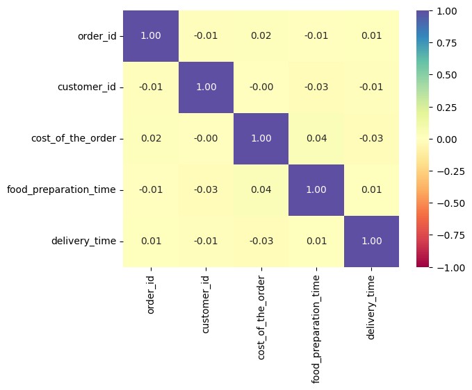

```python
# Plot the heatmap


# Display the relationship of numerical columns (order_id, customer_id, cost_of_the_order, food_preparation_time, delivery_time)
df = data[numeric_cols].corr()

ax = sns.heatmap(data = df, annot = True, vmin = -1, vmax = 1, fmt = '.2f', cmap = 'Spectral')

plt.xticks(rotation = 90)
plt.yticks(rotation = 0)
plt.show()
```

**Observations**

A multivariate analysis of the dataset shows no significant correlations between any of the available variables

### **Question 13:** The company wants to provide a promotional offer in the advertisement of the restaurants. The condition to get the offer is that the restaurants must have a rating count of more than 50 and the average rating should be greater than 4. Find the restaurants fulfilling the criteria to get the promotional offer. [3 marks]

```python
# Get orders with rating and Convert rating column from object to integer
rated_orders = data[data['rating'] != 'Not given'].copy()
rated_orders['rating'] = rated_orders['rating'].astype('int')

# Create a dataframe that contains the restaurant names with their rating counts
rated_orders_count = rated_orders.groupby(['restaurant_name'])['rating'].count().sort_values(ascending = False).reset_index()
rated_orders_count.head()
```

|  | restaurant_name | rating |
| --- | --- | --- |
| 0 | Shake Shack | 133 |
| 1 | The Meatball Shop | 84 |
| 2 | Blue Ribbon Sushi | 73 |
| 3 | Blue Ribbon Fried Chicken | 64 |
| 4 | RedFarm Broadway | 41 |

```python
# Get the restaurant names that have rating count more than 50
rest_names = rated_orders_count[rated_orders_count['rating']>50]['restaurant_name']

# Filter to get orders that that have rating count more than 50
rated_over50_orders = rated_orders[rated_orders['restaurant_name'].isin(rest_names)].copy()

# Group the restaurant names with their ratings and find the mean rating of each restaurant
orders_by_mean_rating = rated_over50_orders.groupby(['restaurant_name'])['rating'].mean().sort_values(ascending = False).reset_index().dropna()

# filter for average rating greater than 4
oredrs_avg_rating_greater_than_4 = orders_by_mean_rating[orders_by_mean_rating['rating'] > 4].sort_values(by='rating', ascending=False).reset_index(drop=True)
oredrs_avg_rating_greater_than_4
```

|  | restaurant_name | rating |
| --- | --- | --- |
| 0 | The Meatball Shop | 4.511905 |
| 1 | Blue Ribbon Fried Chicken | 4.328125 |
| 2 | Shake Shack | 4.278195 |
| 3 | Blue Ribbon Sushi | 4.219178 |

#### **Observations**:

Following are the 4 restaurants that meet the criteria for the promotional offer

1. The Meatball Shop
2. Blue Ribbon Fried Chicken
3. Shake Shack
4. Blue Ribbon Sushi

### **Question 14:** The company charges the restaurant 25% on the orders having cost greater than 20 dollars and 15% on the orders having cost greater than 5 dollars. Find the net revenue generated by the company across all orders. [3 marks]

```python
#function to determine the revenue
def get_revenue(cost):
    if cost > 20:
        return cost*0.25
    elif cost > 5:
        return cost*0.15
    else:
        return cost*0

data['Revenue'] = data['cost_of_the_order'].apply(get_revenue) ## Write the apprpriate column name to compute the revenue
data.head()
```

|  | order_id | customer_id | restaurant_name | cuisine_type | cost_of_the_order | day_of_the_week | rating | food_preparation_time | delivery_time | Revenue |
| --- | --- | --- | --- | --- | --- | --- | --- | --- | --- | --- |
| 0 | 1477147 | 337525 | Hangawi | Korean | 30.75 | Weekend | Not given | 25 | 20 | 7.6875 |
| 1 | 1477685 | 358141 | Blue Ribbon Sushi Izakaya | Japanese | 12.08 | Weekend | Not given | 25 | 23 | 1.8120 |
| 2 | 1477070 | 66393 | Cafe Habana | Mexican | 12.23 | Weekday | 5 | 23 | 28 | 1.8345 |
| 3 | 1477334 | 106968 | Blue Ribbon Fried Chicken | American | 29.20 | Weekend | 3 | 25 | 15 | 7.3000 |
| 4 | 1478249 | 76942 | Dirty Bird to Go | American | 11.59 | Weekday | 4 | 25 | 24 | 1.7385 |

```python
# total revenuw for the company

data['Revenue'].sum()
```

```
np.float64(6166.303)
```

#### **Observations**:

Total revenue generated for all the orders : 6166.30 dollars

### **Question 15:** The company wants to analyze the total time required to deliver the food. What percentage of orders take more than 60 minutes to get delivered from the time the order is placed? (The food has to be prepared and then delivered.) [2 marks]

```python
data['total_time'] =  data['food_preparation_time'] + data['delivery_time']

percentage_oreders_over60minutes = (data[data['total_time']>60].shape[0]/data.shape[0])*100
percentage_oreders_over60minutes
```

```
10.537407797681771
```

#### **Observations**:

About 10.53 % of orders take more than 60 minutes in total.

### **Question 16:** The company wants to analyze the delivery time of the orders on weekdays and weekends. How does the mean delivery time vary during weekdays and weekends? [2 marks]

```python
data.groupby('day_of_the_week')['delivery_time'].mean()
```

| day_of_the_week | delivery_time |
| --- | --- |
| Weekday | 28.340037 |
| Weekend | 22.470022 |

**dtype:** float64

#### **Observations**:

The Mean Delivery time during Weekdays = 28.34

The Mean Delivery time during Weekends = 22.47

### Conclusion and Recommendations

### **Question 17:** What are your conclusions from the analysis? What recommendations would you like to share to help improve the business? (You can use cuisine type and feedback ratings to drive your business recommendations.) [6 marks]

### Conclusions:

The dataset presents a valuable foundation for uncovering operational challenges and growth opportunities. It offers enough granularity to identify where inefficiencies may be impacting customer satisfaction and revenue. Key areas for deeper investigation include food preparation time, delivery time, and customer ratings—each interlinked and crucial to the customer experience.

A quick kitchen loses its edge if followed by sluggish delivery, and vice versa—both directly influence customer ratings. However, the dataset currently lacks the qualitative context behind ratings. Without this, it's difficult to pinpoint what’s driving dissatisfaction or delight. Enriching the dataset with structured customer feedback—such as optional comments or check-box reasons for ratings—would dramatically improve decision-making.

In addition, performance should be reviewed at the restaurant level. Some partners generate low order volume or revenue, potentially draining overall profitability. These need to be assessed not only for their cost-benefit but also their impact on the platform’s brand and service reliability.

### Recommendations:

1. Incentivize customers to provide ratings and brief comments to capture actionable feedback.
2. Track metrics by weekday vs. weekend to reveal performance patterns and inform staffing or logistics adjustments.
3. Identify and support underperforming restaurants with coaching, promotions, or reconsideration of partnership terms.
4. Review the impact of service charges on low-value orders and consider tiered pricing.